# A specialized metabolic network selectively modulates Arabidopsis root microbiota

Ancheng C. Huang,1# Ting Jiang,2,3,4# Yong-Xin Liu,2,3 Yue-Chen Bai,5,6 James Reed,1 Alain Goossens,5,6 Hans-Wilhelm Nützmann,1,ϯ Yang Bai,2,3,4* Anne Osbourn1

2019/2/27

The R markdown mainly includes scripts for visualization 16S amplicon data in thie papers.

## (A) Constrained principal ordination analysis (CPCoA) of Bray-Curtis dissimilarity showing plant genotype effects.

Total number of individual plants used for analyses: Col-0 (n = 12), thas-ko1 (n = 12), thas-ko2 (n = 9), thah-ko (n = 14), thao-ko (n = 13), thaa2-ko (n = 9), thaa2-crispr (n = 12). Biological replicates (individual plants) from two independent experiments (experiment 1 and 2) are indicated by dots and triangles, respectively. Ellipses include 68% of samples from each genotype.

Data filter for OTU table and selected groups

```r
system("mkdir -p fig4")
# Set subset genotype list and order for analysis and visualization
geno_list = c("b3Col","b3ThasKO1","b3ThasKO2","b3ThahKO","b3ThadKO","b3ACT2CR","b3ACT2KO")

# reads experiment design
design = read.table("data/metadata.txt", header=T, row.names=1, sep="\t")
design$group=design$groupID

# Subset genotype
sub_design = subset(design, group %in% geno_list)
# Set group order
sub_design$group  = factor(sub_design$group, levels = geno_list)

# read otutab
beta = read.table(paste("data/otutab.txt",sep=""), header=T, row.names=1, sep="\t", comment.char="")

# Cross screening
idx = rownames(sub_design) %in% colnames(beta)
sub_design=sub_design[idx,]
sub_beta=beta[,rownames(sub_design)]

# Normalization to 100
otutab = as.data.frame(t(sub_beta)/colSums(sub_beta,na=T)*100)

# Filter median of OTU abundance > 0.01% in each group. Total OTUs number from 10659 decreased to 984, variance (total, X & Y) increased.
# Filter by group low abundance
# set initail parameter
design = sub_design
norm = otutab
# get group info
grp = design[, "groupID", drop=F]
# merge by row.names
mat_t2 = merge(grp, norm, by="row.names")
mat_t2 = mat_t2[,-1]
# batch calculate median by
mat_mean = aggregate(mat_t2[,-1], by=mat_t2[1], FUN=median) # mean
mat_mean_final = do.call(rbind, mat_mean)[-1,]
geno = mat_mean$group
colnames(mat_mean_final) = geno
# filter OTU table by median 0.01%
filtered = mat_mean_final[apply(mat_mean_final,1,max) >= 0.01, ] # select OTU at least one sample > 0.1%
otutab = otutab[,rownames(filtered)]
```

CPCoA plot

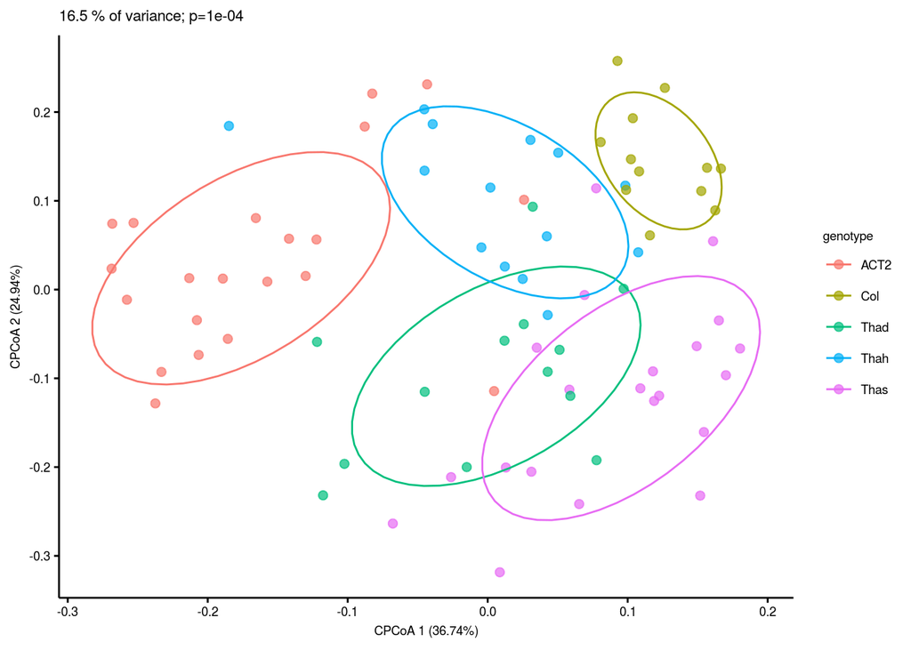

```r
# set distance type
m="bray"

# Constrained analysis OTU table by genotype
capscale.gen = capscale(otutab ~ group, data=sub_design, add=F, sqrt.dist=T, distance= m)

# ANOVA-like permutation analysis
perm_anova.gen = anova.cca(capscale.gen, permutations = 10000, parallel = 9)

# generate variability tables and calculate confidence intervals for the variance
var_tbl.gen = variability_table(capscale.gen)
eig = capscale.gen$CCA$eig
variance = var_tbl.gen["constrained", "proportion"]
p.val = perm_anova.gen[1, 4]

# extract the weighted average (sample) scores
points = capscale.gen$CCA$wa[, 1:2]
points = as.data.frame(points)
points = cbind(points, sub_design)

# plot PC 1 and 2
p = ggplot(points, aes(x=CAP1, y=CAP2, color=genotype)) + geom_point(alpha=.7, size=2) +
    labs(x=paste("CPCoA 1 (", format(100 * eig[1] / sum(eig), digits=4), "%)", sep=""),
    y=paste("CPCoA 2 (", format(100 * eig[2] / sum(eig), digits=4), "%)", sep="")) +
    ggtitle(paste(format(100 * variance,digits=3)," % of variance; p=",format(p.val,digits=2),sep=""))+
    theme_classic() + main_theme
p = p + stat_ellipse(level=0.68)
p
```

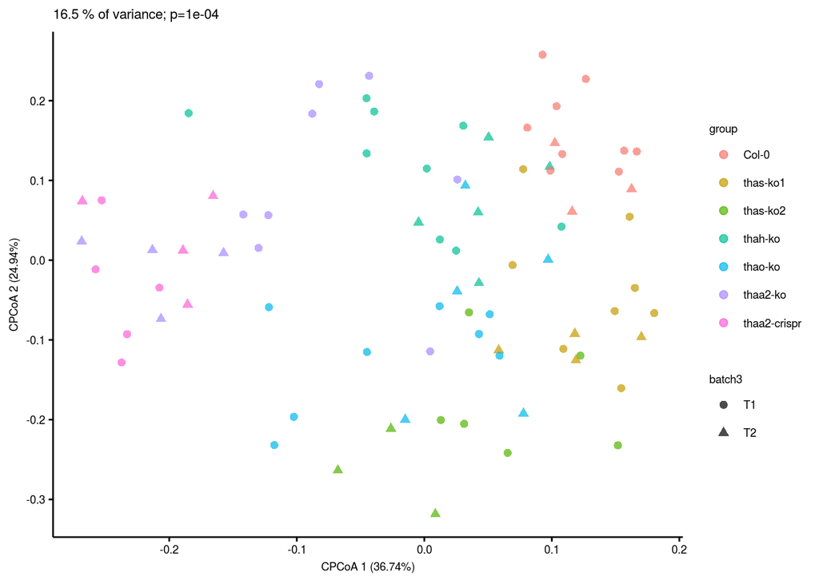

```r
# save pdf
ggsave(paste("fig4/a.cpcoa_stat_", m, ".pdf", sep=""), p, width = 5, height = 3)

# Rename label
levels(points$group) = c("Col-0","thas-ko1","thas-ko2","thah-ko","thao-ko","thaa2-ko","thaa2-crispr")

# add shape by batch3
p = ggplot(points, aes(x=CAP1, y=CAP2, color=group,shape=batch3)) + geom_point(alpha=.7, size=2) +
    labs(x=paste("CPCoA 1 (", format(100 * eig[1] / sum(eig), digits=4), "%)", sep=""),
    y=paste("CPCoA 2 (", format(100 * eig[2] / sum(eig), digits=4), "%)", sep="")) +
    ggtitle(paste(format(100 * variance, digits=3), " % of variance; p=",format(p.val, digits=2),sep="")) +
    theme_classic() + main_theme
p
```

```r
ggsave(paste("fig4/a.cpcoa_shape_", m, ".pdf", sep=""), p, width = 5, height = 3)
```

## (B) Phylum distribution of the root microbiota compositions of the tested A. thaliana genotypes.

As the relative abundance of Proteobacteria is more than 50%, bacteria in this phylum are shown at the class level. # indicates Bacteroidetes significantly higher than that in Col-0 roots at P < 0.05; * indicates Alphaproteobacteria and Deltaproteobacteria significantly lower than that in Col-0 at P < 0.05.

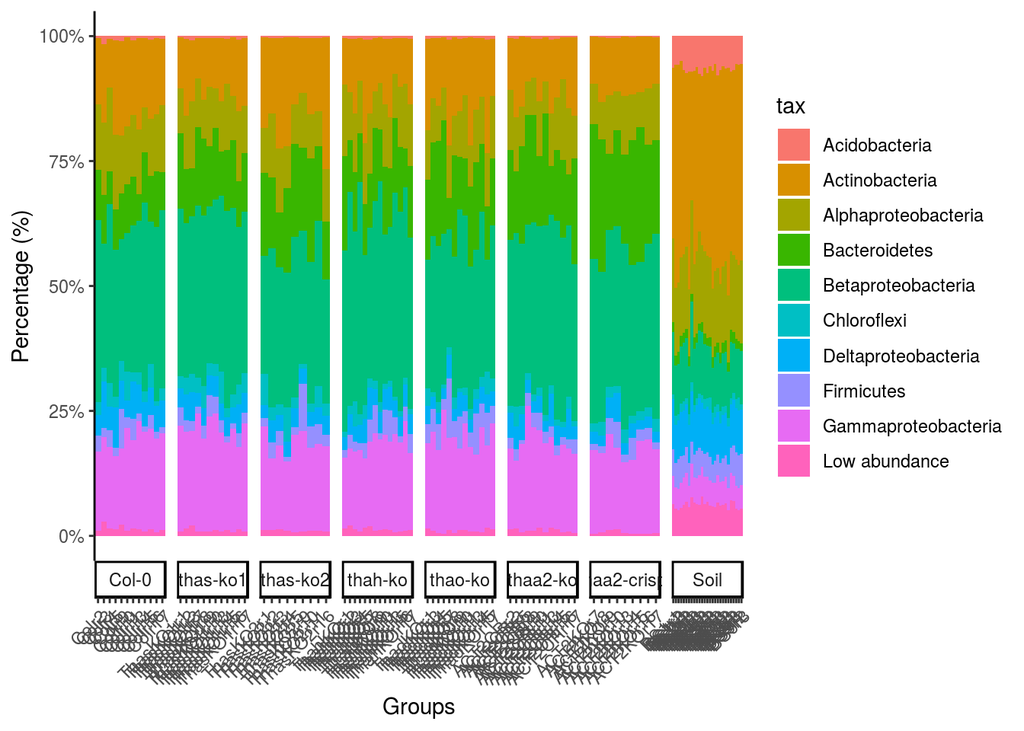

```r
# Set subset genotype list and order for analysis and visualization
geno_list = c("b3Col","b3ThasKO1","b3ThasKO2","b3ThahKO","b3ThadKO","b3ACT2CR","b3ACT2KO","b3BS")

# reads experiment design
design = read.table("data/metadata.txt", header=T, row.names=1, sep="\t")
design$group = design$groupID

sub_design = subset(design, group %in% geno_list)
sub_design$group  = factor(sub_design$group, levels=geno_list)

m="pc"

# usearch tax
tax_sample = read.table(paste("data/taxonomy_", m, ".txt", sep=""), header=T, row.names=1, sep="\t", comment.char="")

# Decreased by abundance
mean_sort = tax_sample[(order(-rowSums(tax_sample))), ]
mean_sort = as.data.frame(mean_sort)
# Only show top 10 phylum, other into Low abundance: control legend number
other = colSums(mean_sort[10:dim(mean_sort)[1], ])
mean_sort = mean_sort[1:(10 - 1), ]
mean_sort = rbind(mean_sort,other)
rownames(mean_sort)[10] = c("Low abundance")

# Cross screenning
idx = rownames(sub_design) %in% colnames(mean_sort)
sub_design=sub_design[idx,]
mean_sort = mean_sort[,rownames(sub_design)]


# Set new variance to part
merge_tax=mean_sort
sampFile = data.frame(sample=row.names(sub_design), group=sub_design$group,row.names = row.names(sub_design))


# 4.1 Stackplot for each samples
write.table("Taxonomy\t\t", file=paste("fig4/c.tax_", m, "_sample.txt",sep=""),append = F, quote = F, eol = "", row.names = F, col.names = F)
suppressWarnings(write.table(merge_tax, file=paste("fig4/c.tax_", m, "_sample.txt",sep=""), append = T, quote = F, sep="\t", eol = "\n", na = "NA", dec = ".", row.names = T, col.names = T))
mean_sort$tax = rownames(mean_sort)
data_all = as.data.frame(melt(mean_sort, id.vars=c("tax")))
data_all = merge(data_all, sampFile, by.x="variable", by.y = "sample")

levels(data_all$group) = c("Col-0","thas-ko1","thas-ko2","thah-ko","thao-ko","thaa2-ko","thaa2-crispr","Soil")

p = ggplot(data_all, aes(x=variable, y = value, fill = tax )) +
    geom_bar(stat = "identity",position="fill", width=1)+
    scale_y_continuous(labels = scales::percent) +
    facet_grid( ~ group, scales = "free_x", switch = "x") +  theme(strip.background = element_blank())+
    theme(axis.ticks.x = element_blank(), axis.text.x = element_blank())+
    xlab("Groups")+ylab("Percentage (%)")+ theme_classic()+theme(axis.text.x=element_text(angle=45,vjust=1, hjust=1))
p
```

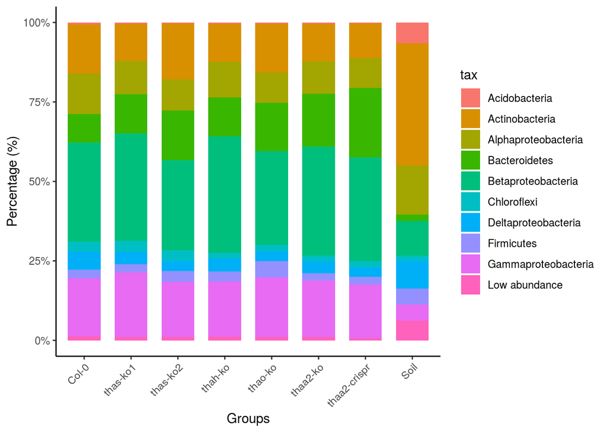

```r
ggsave(paste("fig4/c.tax_", m, "_sample.pdf", sep=""), p, width = 5, height = 3)


# 4.2 Stackplot for group average samples

# merge by group
mat_t = t(merge_tax)
mat_t2 = merge(sampFile, mat_t, by="row.names")
mat_t2 = mat_t2[,c(-1,-2)]
mat_mean = aggregate(mat_t2[,-1], by=mat_t2[1], FUN=mean) # mean
mat_mean_final = do.call(rbind, mat_mean)[-1,]
geno = mat_mean$group
colnames(mat_mean_final) = geno

# save plot text
mean_sort=as.data.frame(mat_mean_final)
write.table("Taxonomy\t", file=paste("fig4/c.tax_", m, "_group.txt",sep=""),append = F, quote = F, eol = "", row.names = F, col.names = F)
suppressWarnings(write.table(mean_sort, file=paste("fig4/c.tax_", m, "_group.txt",sep=""), append = T, quote = F, sep="\t", eol = "\n", na = "NA", dec = ".", row.names = T, col.names = T))

mean_sort$tax = rownames(mean_sort)
data_all = as.data.frame(melt(mean_sort, id.vars=c("tax")))
levels(data_all$variable) = c("Col-0","thas-ko1","thas-ko2","thah-ko","thao-ko","thaa2-ko","thaa2-crispr","Soil")
p = ggplot(data_all, aes(x=variable, y = value, fill = tax )) +
  geom_bar(stat = "identity",position="fill", width=0.7)+
  scale_y_continuous(labels = scales::percent) +
  xlab("Groups")+ylab("Percentage (%)")+ theme_classic()
if (length(unique(data_all$variable))>3){
    p=p+theme(axis.text.x=element_text(angle=45,vjust=1, hjust=1))
}
p
```

```r
ggsave(paste("fig4/c.tax_", m, "_group.pdf", sep=""), p, width = 5, height = 3)
```

### (C) Depleted in rice, wheat and triterpene mutants vs Col-0

```r
library(VennDiagram)
```

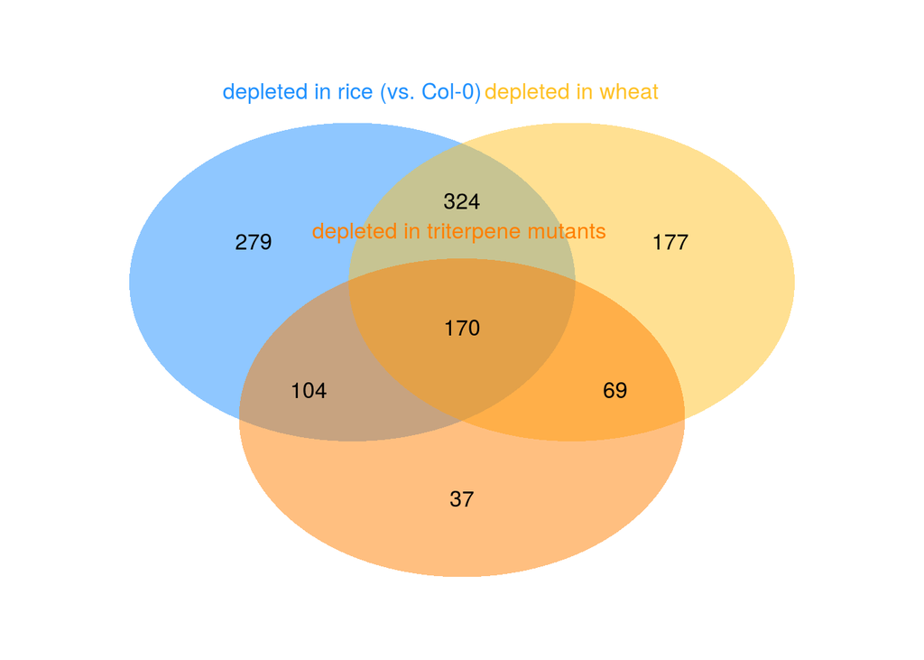

```r
num =3
data <- read.table(file="data/diff.list", sep="\t", quote="")
RiceCp35_b3Col_D <- data[grepl("\\<RiceCp35_b3Col_D\\>",data[,2]),1]
WheatD35L1_b3Col_D <- data[grepl("\\<WheatD35L1_b3Col_D\\>",data[,2]),1]
All3T_D <- data[grepl("\\<All3T_D\\>",data[,2]),1]
color_v <- c("dodgerblue", "goldenrod1", "darkorange1", "seagreen3", "orchid3")[1:num]
p <- venn.diagram(
    x = list("depleted in rice (vs. Col-0)"=RiceCp35_b3Col_D, "depleted in wheat"=WheatD35L1_b3Col_D, "depleted in triterpene mutants "=All3T_D),
    filename = NULL, col = "transparent",
    fill = color_v,
    alpha = 0.50,
    label.col = c("black"),
    cex = 1, fontfamily = "Helvetica",
    cat.default.pos="outer",
    cat.pos=0, margin=0.1,
    cat.col = color_v,cat.cex = 1, cat.fontfamily = "Helvetica"
)
grid.draw(p)
```

Permuatation test for overlapped rice and wheat common vs Arabidopsis

```r
# Set number in each set
total = 1349
overlap=170
n1=overlap+324
n2=overlap+104+69+37
# Set title
title="rice_wheat_ath_depleted"

# Set sample times
n=100000

null <- vector("numeric",n)
for (i in 1:n) {
  set.seed(i)
  A = sample(1:total, n1)
  set.seed(n+i)
  B = sample(1:total, n2)
  null[i] <- length( intersect(A, B))
}
pvalue = length(null[null>=overlap])/length(null)
pvalue
```

```
## [1] 4e-05
```

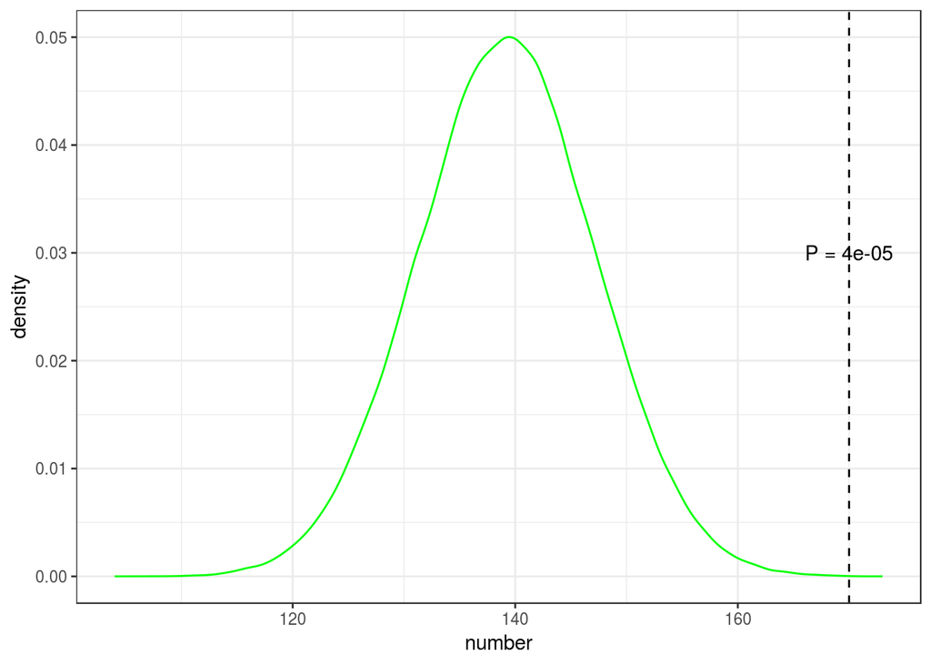

```r
# ggplot visualization
df = as.data.frame(null)
colnames(df)="number"
p = ggplot(df, aes(x=number))+geom_line(stat="density", colour = "green")+ theme_bw()+
  geom_vline(xintercept=overlap, linetype=2)+annotate("text",x=overlap,y=0.03, label=paste("P = ", pvalue, sep=""))
ggsave(paste("fig4/c.",title,total,n1,n2,overlap,".pdf", sep="."), p, width = 5, height = 3)
p
```

### (D) depleted in rice, wheat and enriched in triterpene mutants vs Col-0

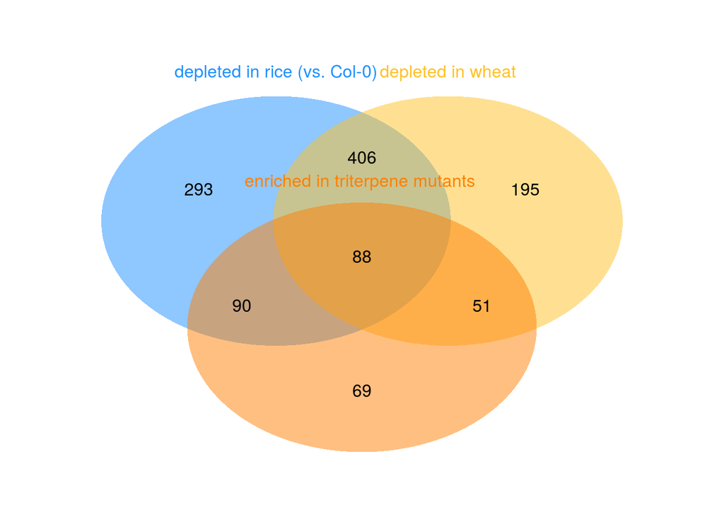

```r
library(VennDiagram)
num =3
data <- read.table(file="data/diff.list", sep="\t", quote="")
RiceCp35_b3Col_D <- data[grepl("\\<RiceCp35_b3Col_D\\>",data[,2]),1]
WheatD35L1_b3Col_D <- data[grepl("\\<WheatD35L1_b3Col_D\\>",data[,2]),1]
All3T_E <- data[grepl("\\<All3T_E\\>",data[,2]),1]
color_v <- c("dodgerblue", "goldenrod1", "darkorange1", "seagreen3", "orchid3")[1:num]
p <- venn.diagram(
    x = list("depleted in rice (vs. Col-0)"=RiceCp35_b3Col_D, "depleted in wheat"=WheatD35L1_b3Col_D, "enriched in triterpene mutants "=All3T_E),
    filename = NULL, col = "transparent",
    fill = color_v,
    alpha = 0.50,
    label.col = c("black"),
    cex = 1, fontfamily = "Helvetica",
    cat.default.pos="outer",
    cat.pos=0, margin=0.1,
    cat.col = color_v,cat.cex = 1, cat.fontfamily = "Helvetica"
)
grid.draw(p)
```

Permuatation test for overlapped rice and wheat common vs Arabidopsis

```r
# Set number in each set
total = 1349
overlap=88
n1=overlap+406
n2=overlap+90+51+69
# Set title
title="rice_wheat_ath_DDE"

# Set sample times
n=100000

null <- vector("numeric",n)
for (i in 1:n) {
  set.seed(i)
  A = sample(1:total, n1)
  set.seed(n+i)
  B = sample(1:total, n2)
  null[i] <- length( intersect(A, B))
}
pvalue = length(null[null>=overlap])/length(null)
pvalue
```

```
## [1] 0.99834
```

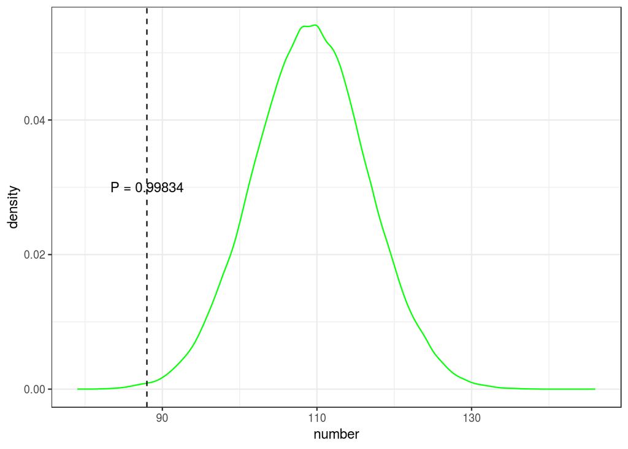

```r
# ggplot visualization
df = as.data.frame(null)
colnames(df)="number"
p = ggplot(df, aes(x=number))+geom_line(stat="density", colour = "green")+ theme_bw()+
  geom_vline(xintercept=overlap, linetype=2)+annotate("text",x=overlap,y=0.03, label=paste("P = ", pvalue, sep=""))
ggsave(paste("fig4/c.",title,total,n1,n2,overlap,".pdf", sep="."), p, width = 5, height = 3)
p
```